# Name of Paddock analysis

## plot of biomass vs survey data

Linnear model

Confirm the sampling size I have assumed 2*1m cuts with 60cm row spacing (revised 2/9/2022)

Note that there are a few high biomass values, these are in the buffer and reflect the better soil.

```
##  [1] "FID"        "name"       "Sample"     "Lat"        "Long"
##  [6] "Plant___Ba" "Bag_wt"     "Plant_wt"   "Comment"    "biomass_Kg"
## [11] "timing"     "PhenNDR_po" "PhenLAI_po" "PhenDIS_po" "CC_NDVI_po"
## [16] "CC_LAI_po"  "CC_Dist_po" "POINT_X"    "POINT_Y"
```

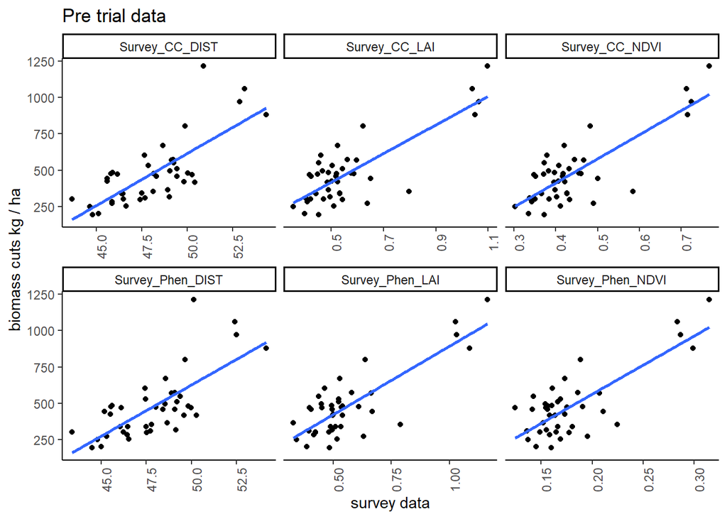

## The fit of models biomass vs survey data

[output not shown]

The Crop Circle LAI has the correlations (0.80) but the R2 is 0.65. We used CC LAI in the pre analysis - so it makes good sense to use this.

`summary(lm( kg_ha~ value, data = post_trial_biomass_long_CC_LAI_no))`

```
##
## Call:
## lm(formula = kg_ha ~ value, data = post_trial_biomass_long_CC_LAI_no)
##
## Residuals:
##     Min      1Q  Median      3Q     Max
## -356.17  -87.50  -12.43  103.03  262.75
##
## Coefficients:
##             Estimate Std. Error t value Pr(>|t|)
## (Intercept)   -71.14      68.49  -1.039    0.305
## value         981.23     116.03   8.457 2.35e-10 ***
## ---
## Signif. codes:  0 '***' 0.001 '**' 0.01 '*' 0.05 '.' 0.1 ' ' 1
##
## Residual standard error: 136.2 on 39 degrees of freedom
## Multiple R-squared:  0.6471, Adjusted R-squared:  0.6381
## F-statistic: 71.52 on 1 and 39 DF,  p-value: 2.353e-10
```

### Best option for converting survey data to biomass in kg/ha

biomass = intercept + slope * survey

### Grids of biomass

Converted using the values and grids outlined above.

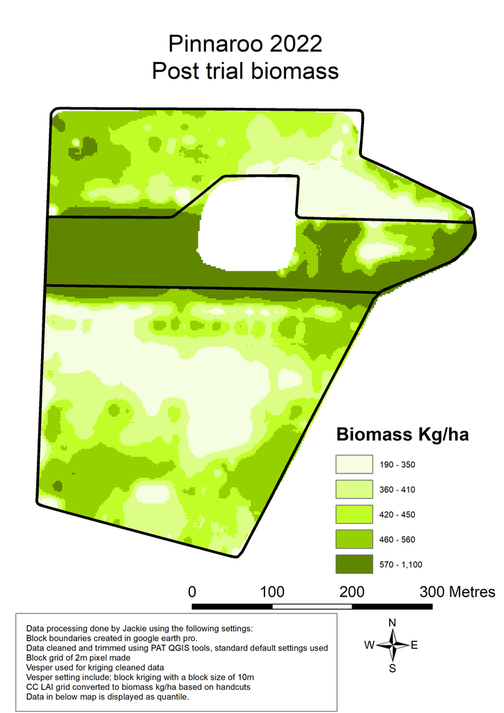